# Lab 2: Spatial Analysis and Visualization

Healthcare Access and Equity in Pennsylvania

Author

Indrajeet Chavan

Published

February 23, 2026

## Assignment Overview

**Learning Objectives:** - Apply spatial operations to answer policy-relevant research questions - Integrate census demographic data with spatial analysis - Create publication-quality visualizations and maps - Work with spatial data from multiple sources - Communicate findings effectively for policy audiences

## Part 1: Healthcare Access for Vulnerable Populations

### Research Question

**Which Pennsylvania counties have the highest proportion of vulnerable populations (elderly + low-income) living far from hospitals?**

Your analysis should identify counties that should be priorities for healthcare investment and policy intervention.

### Required Analysis Steps

Complete the following analysis, documenting each step with code and brief explanations:

#### Step 1: Data Collection (5 points)

Load the required spatial data: - Pennsylvania county boundaries - Pennsylvania hospitals (from lecture data) - Pennsylvania census tracts

**Your Task:**

```r
#Clearing previous data
rm(list=ls())

# Load required packages
library(tidyverse)
library(tidycensus)
library(dplyr)
library(sf)
library(tigris)
library(scales)
library(patchwork)
library(here)

options(tigris_use_cache = TRUE)

setwd("/Users/indrajeetchavan/Library/CloudStorage/OneDrive-PennO365/Penn/6. Penn Sem 2/CPLN 5920 PPA/GitHub/IC_PPARep/Labs/Labs_2")

# Load spatial data
pa_counties <- st_read(here("/Users/indrajeetchavan/Library/CloudStorage/OneDrive-PennO365/Penn/6. Penn Sem 2/CPLN 5920 PPA/GitHub/IC_PPARep/Labs/Labs_2/Data/Pennsylvania_County_Boundaries.shp"))
districts <- st_read(here("/Users/indrajeetchavan/Library/CloudStorage/OneDrive-PennO365/Penn/6. Penn Sem 2/CPLN 5920 PPA/GitHub/IC_PPARep/Labs/Labs_2/Data/districts.geojson"))
hospitals <- st_read(here("/Users/indrajeetchavan/Library/CloudStorage/OneDrive-PennO365/Penn/6. Penn Sem 2/CPLN 5920 PPA/GitHub/IC_PPARep/Labs/Labs_2/Data/hospitals.geojson"))
census_tracts <- tracts(state = "PA", cb = TRUE)
metro_areas <- core_based_statistical_areas(cb = TRUE)

# Check that all data loaded correctly
nrow(hospitals)
```

```
[1] 223
```

```r
nrow(census_tracts)
```

```
[1] 3445
```

```r
# Check CRS
st_crs(pa_counties)
```

```
Coordinate Reference System:
  User input: WGS 84 / Pseudo-Mercator
  wkt:
PROJCRS["WGS 84 / Pseudo-Mercator",
    BASEGEOGCRS["WGS 84",
        ENSEMBLE["World Geodetic System 1984 ensemble",
            MEMBER["World Geodetic System 1984 (Transit)"],
            MEMBER["World Geodetic System 1984 (G730)"],
            MEMBER["World Geodetic System 1984 (G873)"],
            MEMBER["World Geodetic System 1984 (G1150)"],
            MEMBER["World Geodetic System 1984 (G1674)"],
            MEMBER["World Geodetic System 1984 (G1762)"],
            MEMBER["World Geodetic System 1984 (G2139)"],
            MEMBER["World Geodetic System 1984 (G2296)"],
            ELLIPSOID["WGS 84",6378137,298.257223563,
                LENGTHUNIT["metre",1]],
            ENSEMBLEACCURACY[2.0]],
        PRIMEM["Greenwich",0,
            ANGLEUNIT["degree",0.0174532925199433]],
        ID["EPSG",4326]],
    CONVERSION["Popular Visualisation Pseudo-Mercator",
        METHOD["Popular Visualisation Pseudo Mercator",
            ID["EPSG",1024]],
        PARAMETER["Latitude of natural origin",0,
            ANGLEUNIT["degree",0.0174532925199433],
            ID["EPSG",8801]],
        PARAMETER["Longitude of natural origin",0,
            ANGLEUNIT["degree",0.0174532925199433],
            ID["EPSG",8802]],
        PARAMETER["False easting",0,
            LENGTHUNIT["metre",1],
            ID["EPSG",8806]],
        PARAMETER["False northing",0,
            LENGTHUNIT["metre",1],
            ID["EPSG",8807]]],
    CS[Cartesian,2],
        AXIS["easting (X)",east,
            ORDER[1],
            LENGTHUNIT["metre",1]],
        AXIS["northing (Y)",north,
            ORDER[2],
            LENGTHUNIT["metre",1]],
    USAGE[
        SCOPE["Web mapping and visualisation."],
        AREA["World between 85.06°S and 85.06°N."],
        BBOX[-85.06,-180,85.06,180]],
    ID["EPSG",3857]]
```

```r
st_crs(hospitals)
```

```
Coordinate Reference System:
  User input: WGS 84
  wkt:
GEOGCRS["WGS 84",
    DATUM["World Geodetic System 1984",
        ELLIPSOID["WGS 84",6378137,298.257223563,
            LENGTHUNIT["metre",1]]],
    PRIMEM["Greenwich",0,
        ANGLEUNIT["degree",0.0174532925199433]],
    CS[ellipsoidal,2],
        AXIS["geodetic latitude (Lat)",north,
            ORDER[1],
            ANGLEUNIT["degree",0.0174532925199433]],
        AXIS["geodetic longitude (Lon)",east,
            ORDER[2],
            ANGLEUNIT["degree",0.0174532925199433]],
    ID["EPSG",4326]]
```

```r
st_crs(census_tracts)
```

```
Coordinate Reference System:
  User input: NAD83
  wkt:
GEOGCRS["NAD83",
    DATUM["North American Datum 1983",
        ELLIPSOID["GRS 1980",6378137,298.257222101,
            LENGTHUNIT["metre",1]]],
    PRIMEM["Greenwich",0,
        ANGLEUNIT["degree",0.0174532925199433]],
    CS[ellipsoidal,2],
        AXIS["latitude",north,
            ORDER[1],
            ANGLEUNIT["degree",0.0174532925199433]],
        AXIS["longitude",east,
            ORDER[2],
            ANGLEUNIT["degree",0.0174532925199433]],
    ID["EPSG",4269]]
```

**Questions to answer:** - How many hospitals are in your dataset? **223 Hospitals**

- How many census tracts? **3445 Census tracts**
- What coordinate reference system is each dataset in? **Co ordinate systems are as follows:** **1. pa_counties : EPSG:3857 (WGS 84)** **2. hospitals : EPSG:4326 (WGS 84)** **3. census_tracts : EPSG:4269 (NAD83)**

#### Step 2: Get Demographic Data

Use `tidycensus` to download tract-level demographic data for Pennsylvania.

**Required variables:** - Total population - Median household income - Population 65 years and over (you may need to sum multiple age categories)

**Your Task:**

```r
# Get demographic data from ACS
acs_vars <- c(
  total_pop = "B01003_001",
  median_income = "B19013_001",
  age_65_66 = "B01001_020",
  age_67_69 = "B01001_021",
  age_70_74 = "B01001_022",
  age_75_79 = "B01001_023",
  age_80_84 = "B01001_024",
  age_85plus = "B01001_025",
  age_65_66_f = "B01001_044",
  age_67_69_f = "B01001_045",
  age_70_74_f = "B01001_046",
  age_75_79_f = "B01001_047",
  age_80_84_f = "B01001_048",
  age_85plus_f = "B01001_049"
)

acs_data <- get_acs(
  geography = "tract",
  variables = acs_vars,
  state = "PA",
  year = 2022,
  geometry = FALSE
)

# Pivot wider
acs_wide <- acs_data %>%
  select(GEOID, variable, estimate) %>%
  pivot_wider(names_from = variable, values_from = estimate)

# Calculate elderly population
acs_wide <- acs_wide %>%
  mutate(
    elderly_pop = age_65_66 + age_67_69 + age_70_74 +
                  age_75_79 + age_80_84 + age_85plus +
                  age_65_66_f + age_67_69_f + age_70_74_f +
                  age_75_79_f + age_80_84_f + age_85plus_f,
    elderly_pct = elderly_pop / total_pop
  )

# Join to tract boundaries
# Join to spatial tracts
tracts_pa <- census_tracts %>%
  left_join(acs_wide, by = "GEOID")

#tracts have missing income data
sum(is.na(tracts_pa$median_income))
```

```
[1] 62
```

```r
#median income across all PA census tracts
median(tracts_pa$median_income, na.rm = TRUE)
```

```
[1] 70188
```

**Questions to answer:** - What year of ACS data are you using? **ACS Year: 2022 (5-year)**

- How many tracts have missing income data? **62 Census Tracts**
- What is the median income across all PA census tracts? **70188**

#### Step 3: Define Vulnerable Populations

Identify census tracts with vulnerable populations based on TWO criteria: 1. Low median household income (choose an appropriate threshold) 2. Significant elderly population (choose an appropriate threshold)

**Your Task:**

```r
# Filter for vulnerable tracts based on your criteria
#Income Threshold: Low Income groups below median income of PA
state_median_income <- median(tracts_pa$median_income, na.rm = TRUE)

#Vulnerable Population: Low Income groups below median income of PA & high elderly population
vulnerable_tracts <- tracts_pa %>%
  mutate(
    low_income = median_income < state_median_income,
    high_elderly = elderly_pct >= 0.15,
    vulnerable = low_income & high_elderly
  )

#Count of Vulnerable tracts
sum(vulnerable_tracts$vulnerable, na.rm = TRUE)
```

```
[1] 1125
```

```r
#percentage of PA census tracts are considered vulnerable
mean(vulnerable_tracts$vulnerable, na.rm = TRUE) * 100
```

```
[1] 33.02025
```

**Questions to answer:** - What income threshold did you choose and why? **Low income groups with income below PA median income value**

- What elderly population threshold did you choose and why? **High elderly population determined by tracts with ≥ 15% population age 65+**
- How many tracts meet your vulnerability criteria? **1125 Census Tracts**
- What percentage of PA census tracts are considered vulnerable by your definition? **33.02025 % tracts**

#### Step 4: Calculate Distance to Hospitals

For each vulnerable tract, calculate the distance to the nearest hospital.

**Your Task:**

```r
# Transform to appropriate projected CRS
#Using Pennsylvania South State Plane:EPSG: 32129 (good for distance in meters)

# Transform
tracts_proj <- st_transform(vulnerable_tracts, 32129)
hospitals_proj <- st_transform(hospitals, 32129)

# Get centroids
tract_centroids <- st_centroid(tracts_proj)

# Calculate distance from each tract centroid to nearest hospital
dist_matrix <- st_distance(tract_centroids, hospitals_proj)

nearest_dist <- apply(dist_matrix, 1, min)

# Convert meters to miles
tracts_proj$dist_miles <- as.numeric(nearest_dist) / 1609.34

#Separating vulnerable tracts
vulnerable_only <- tracts_proj %>%
  filter(vulnerable == TRUE)

#Finding the distance stats
mean(vulnerable_only$dist_miles, na.rm = TRUE)
```

```
[1] 5.310786
```

```r
max(vulnerable_only$dist_miles, na.rm = TRUE)
```

```
[1] 29.11601
```

```r
sum(vulnerable_only$dist_miles > 15, na.rm = TRUE)
```

```
[1] 64
```

**Requirements:** - Use an appropriate projected coordinate system for Pennsylvania - Calculate distances in miles - Explain why you chose your projection

**We are using the Pennsylvania South State Plane:EPSG: 32129 as it is good for calculating distance in meters which can be later converted into miles.**

**Questions to answer:** - What is the average distance to the nearest hospital for vulnerable tracts? **5.310786 miles**

- What is the maximum distance? **29.11601 miles**
- How many vulnerable tracts are more than 15 miles from the nearest hospital? **64 Tracts**

#### Step 5: Identify Underserved Areas

Define “underserved” as vulnerable tracts that are more than 15 miles from the nearest hospital.

**Your Task:**

```r
# Create underserved variable
tracts_proj <- tracts_proj %>%
  mutate(underserved = vulnerable & dist_miles > 15)

#Number of tracts that are underserved
sum(tracts_proj$underserved, na.rm = TRUE)
```

```
[1] 64
```

```r
#percentage of vulnerable tracts that are underserved
mean(tracts_proj$underserved[tracts_proj$vulnerable], na.rm = TRUE) * 100
```

```
[1] 5.688889
```

**Questions to answer:** - How many tracts are underserved? **64 tracts**

- What percentage of vulnerable tracts are underserved? **5.688889 %**
- Does this surprise you? Why or why not? **Not entirely as at first glance, 5.7% seems small. I would expect a much larger share of vulnerable tracts to be far from hospitals, especially in a state as geographically large as Pennsylvania. However, there are a few reasons this percentage makes sense. The reasons include:** **1. Pennsylvania Has Strong Hospital Coverage** **2. Vulnerability and long-distance access don’t always overla** **3. Fifteen miles is a fairly large service radius** **4. Though small, the percentage can still represent a huge population based on which tracts come under these tracts.**

#### Step 6: Aggregate to County Level

Use spatial joins and aggregation to calculate county-level statistics about vulnerable populations and hospital access.

**Your Task:**

```r
# Spatial join tracts to counties

# Transform counties
counties_proj <- st_transform(pa_counties, 32129)

# Spatial join
tracts_county <- st_join(tracts_proj, counties_proj)

#highest percentage of underserved vulnerable tracts
county_summary <- tracts_county %>%
  st_drop_geometry() %>%
  group_by(NAMELSADCO) %>%
  summarise(
    vulnerable_tracts = sum(vulnerable, na.rm = TRUE),
    underserved_tracts = sum(underserved, na.rm = TRUE),
    pct_underserved = underserved_tracts / vulnerable_tracts,
    avg_dist = mean(dist_miles[vulnerable], na.rm = TRUE),
    total_vulnerable_pop = sum(elderly_pop[vulnerable], na.rm = TRUE)
  ) %>%
  arrange(desc(pct_underserved))

#the most vulnerable people living far from hospitals
county_summary <- tracts_county %>%
  st_drop_geometry() %>%
  group_by(NAMELSADCO) %>%
  summarise(
    vulnerable_tracts = sum(vulnerable, na.rm = TRUE),
    underserved_tracts = sum(underserved, na.rm = TRUE),
    pct_underserved = underserved_tracts / vulnerable_tracts,
    avg_dist = mean(dist_miles[vulnerable], na.rm = TRUE),
    total_vulnerable_pop = sum(elderly_pop[vulnerable], na.rm = TRUE)
  ) %>%
  arrange(desc(total_vulnerable_pop))

# Aggregate statistics by county
head(county_summary, 5)
```

```
# A tibble: 5 × 6
  NAMELSADCO       vulnerable_tracts underserved_tracts pct_underserved avg_dist
  <chr>                        <int>              <int>           <dbl>    <dbl>
1 Philadelphia Co…               111                  0               0     1.31
2 Allegheny County               148                  0               0     2.56
3 Westmoreland Co…                85                  0               0     4.90
4 Luzerne County                  59                  0               0     4.56
5 Cambria County                  52                  0               0     6.29
# ℹ 1 more variable: total_vulnerable_pop <dbl>
```

**Required county-level statistics:** - Number of vulnerable tracts - Number of underserved tracts  
- Percentage of vulnerable tracts that are underserved - Average distance to nearest hospital for vulnerable tracts - Total vulnerable population

**Questions to answer:** - Which 5 counties have the highest percentage of underserved vulnerable tracts? **The counties that have the highest percentage of underserved vulnerable tracts are Cameron County, Forest County, Sullivan County, Pike County and Snyder County.**

#### Step 7: Create Summary Table

Create a professional table showing the top 10 priority counties for healthcare investment.

**Your Task:**

```r
# Create and format priority counties table
library(knitr)

priority_table <- county_summary %>%
  slice_max(pct_underserved, n = 10)

kable(priority_table,
      caption = "Top 10 Priority Counties for Healthcare Investment",
      digits = 2)
```

Top 10 Priority Counties for Healthcare Investment

| NAMELSADCO | vulnerable_tracts | underserved_tracts | pct_underserved | avg_dist | total_vulnerable_pop |
| --- | --- | --- | --- | --- | --- |
| Forest County | 8 | 8 | 1.00 | 18.40 | 6372 |
| Cameron County | 7 | 7 | 1.00 | 19.35 | 5474 |
| Sullivan County | 9 | 9 | 1.00 | 20.31 | 3700 |
| Pike County | 11 | 8 | 0.73 | 17.40 | 5423 |
| Snyder County | 17 | 12 | 0.71 | 16.11 | 18298 |
| Juniata County | 15 | 10 | 0.67 | 15.34 | 11988 |
| Clearfield County | 31 | 13 | 0.42 | 14.07 | 24894 |
| Union County | 11 | 4 | 0.36 | 12.25 | 8487 |
| Dauphin County | 22 | 7 | 0.32 | 8.58 | 15255 |
| Centre County | 16 | 5 | 0.31 | 10.40 | 11247 |

**Requirements:** - Use `knitr::kable()` or similar for formatting - Include descriptive column names - Format numbers appropriately (commas for population, percentages, etc.) - Add an informative caption - Sort by priority (you decide the metric)

## Part 2: Comprehensive Visualization

Using the skills from Week 3 (Data Visualization), create publication-quality maps and charts.

### Map 1: County-Level Choropleth

Create a choropleth map showing healthcare access challenges at the county level.

**Your Task:**

[figure not shown]

```r
# Create county-level access map
c1 <- c("COUNTY_NAM", "vulnerable_tracts", "undeserved_tracts", "pct_undeserved", "avg_dist", "total_vulnerable_pop")
county_summary <- county_summary %>%
  mutate(colnames(c1))

county_map <- counties_proj %>%
  left_join(county_summary, by = c("COUNTY_NAM" = "NAMELSADCO"))

#a choropleth map showing healthcare access challenge
ggplot() +
  geom_sf(data = county_map, aes(fill = pct_underserved), color = "white") +
  geom_sf(data = hospitals_proj, size = 1, color = "black") +
  scale_fill_viridis_c(labels = percent_format()) +
  labs(
    title = "Healthcare Access Challenges in Pennsylvania",
    subtitle = "Percent of Vulnerable Tracts More Than 15 Miles from Hospital",
    fill = "% Underserved",
    caption = "Source: ACS 2022, Hospital Data"
  ) +
  theme_void()
```

**Requirements:** - Fill counties by percentage of vulnerable tracts that are underserved - Include hospital locations as points - Use an appropriate color scheme - Include clear title, subtitle, and caption - Use `theme_void()` or similar clean theme - Add a legend with formatted labels

### Map 2: Detailed Vulnerability Map

Create a map highlighting underserved vulnerable tracts.

**Your Task:**

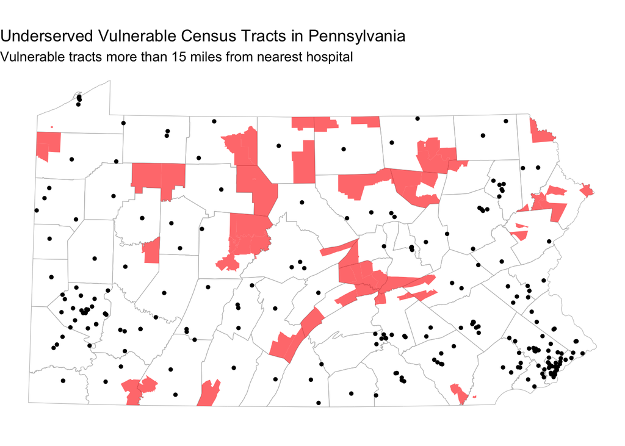

```r
# Create detailed tract-level map

ggplot() +
  geom_sf(data = counties_proj, fill = NA, color = "gray") +
  geom_sf(data = tracts_proj %>% filter(underserved),
          fill = "red", color = NA, alpha = 0.6) +
  geom_sf(data = hospitals_proj, size = 1) +
  labs(
    title = "Underserved Vulnerable Census Tracts in Pennsylvania",
    subtitle = "Vulnerable tracts more than 15 miles from nearest hospital"
  ) +
  theme_void()
```

**Requirements:** - Show underserved vulnerable tracts in a contrasting color - Include county boundaries for context - Show hospital locations - Use appropriate visual hierarchy (what should stand out?) - Include informative title and subtitle

### Chart: Distribution Analysis

Create a visualization showing the distribution of distances to hospitals for vulnerable populations.

**Your Task:**

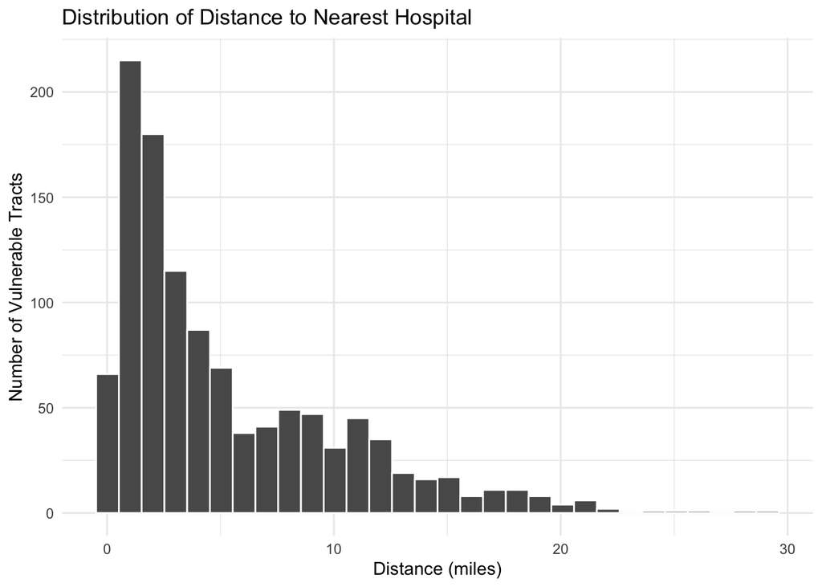

```r
# Create distribution visualization

ggplot(vulnerable_only, aes(x = dist_miles)) +
  geom_histogram(bins = 30, color ="white") +
  labs(
    title = "Distribution of Distance to Nearest Hospital",
    x = "Distance (miles)",
    y = "Number of Vulnerable Tracts"
  ) +
  theme_minimal()
```

**Suggested chart types:** - Histogram or density plot of distances - Box plot comparing distances across regions - Bar chart of underserved tracts by county - Scatter plot of distance vs. vulnerable population size

**Requirements:** - Clear axes labels with units - Appropriate title - Professional formatting - Brief interpretation (1-2 sentences as a caption or in text)

## Part 3: Bring Your Own Data Analysis

Choose your own additional spatial dataset and conduct a supplementary analysis.

### Challenge Options

I have choosen Environmental Justice for my own research question using OpenDataPhilly data (https://opendataphilly.org/datasets/).

**Note these are just loose suggestions to spark ideas - follow or make your own as the data permits and as your ideas evolve. This analysis should include bringing in your own dataset, ensuring the projection/CRS of your layers align and are appropriate for the analysis (not lat/long or geodetic coordinate systems). The analysis portion should include some combination of spatial and attribute operations to answer a relatively straightforward question**

#### Environmental Justice

**Option C: Green Space Equity** - **Data:** Parks, Street Trees, Census tracts (race/income demographics) - **Question:** “Do low-income and minority neighborhoods have equitable access to green space?” - **Operations:** Buffer parks (10-minute walk = 0.5 mile), calculate tree canopy or park acreage per capita, compare by demographics - **Policy relevance:** Climate resilience, environmental justice, urban forestry investment

### Data Sources

**OpenDataPhilly:** https://opendataphilly.org/datasets/ - Most datasets available as GeoJSON, Shapefile, or CSV with coordinates - Always check the Metadata for a data dictionary of the fields.

**Additional Sources:** - **Pennsylvania Open Data:** https://data.pa.gov/ - **Census Bureau (via tidycensus):** Demographics, economic indicators, commute patterns - **TIGER/Line (via tigris):** Geographic boundaries

### Your Analysis

**Your Task:**

1. **Find and load additional data**
   - Document your data source
   - Check and standardize the CRS
   - Provide basic summary statistics

```r
# Load your additional dataset
library(sf)
library(tidyverse)
library(tidycensus)
library(tigris)

options(tigris_use_cache = TRUE)

# Load Philadelphia tracts
phl_tracts <- tracts(state = "PA", county = "Philadelphia", year = 2022)

# Load parks layer (downloaded from OpenDataPhilly)
parks <- st_read("/Users/indrajeetchavan/Library/CloudStorage/OneDrive-PennO365/Penn/6. Penn Sem 2/CPLN 5920 PPA/GitHub/IC_PPARep/Labs/Labs_2/Data/PPR_Districts_2018-shp/6f10cbdb-1ec2-4b34-be5a-4e6161932270202041-1-20jrvr.q31lf.shp")
# Check CRS
st_crs(phl_tracts)
```

```
Coordinate Reference System:
  User input: NAD83
  wkt:
GEOGCRS["NAD83",
    DATUM["North American Datum 1983",
        ELLIPSOID["GRS 1980",6378137,298.257222101,
            LENGTHUNIT["metre",1]]],
    PRIMEM["Greenwich",0,
        ANGLEUNIT["degree",0.0174532925199433]],
    CS[ellipsoidal,2],
        AXIS["latitude",north,
            ORDER[1],
            ANGLEUNIT["degree",0.0174532925199433]],
        AXIS["longitude",east,
            ORDER[2],
            ANGLEUNIT["degree",0.0174532925199433]],
    ID["EPSG",4269]]
```

```r
st_crs(parks)
```

```
Coordinate Reference System:
  User input: NAD83 / Pennsylvania South (ftUS)
  wkt:
PROJCRS["NAD83 / Pennsylvania South (ftUS)",
    BASEGEOGCRS["NAD83",
        DATUM["North American Datum 1983",
            ELLIPSOID["GRS 1980",6378137,298.257222101,
                LENGTHUNIT["metre",1]]],
        PRIMEM["Greenwich",0,
            ANGLEUNIT["degree",0.0174532925199433]],
        ID["EPSG",4269]],
    CONVERSION["SPCS83 Pennsylvania South zone (US survey foot)",
        METHOD["Lambert Conic Conformal (2SP)",
            ID["EPSG",9802]],
        PARAMETER["Latitude of false origin",39.3333333333333,
            ANGLEUNIT["degree",0.0174532925199433],
            ID["EPSG",8821]],
        PARAMETER["Longitude of false origin",-77.75,
            ANGLEUNIT["degree",0.0174532925199433],
            ID["EPSG",8822]],
        PARAMETER["Latitude of 1st standard parallel",40.9666666666667,
            ANGLEUNIT["degree",0.0174532925199433],
            ID["EPSG",8823]],
        PARAMETER["Latitude of 2nd standard parallel",39.9333333333333,
            ANGLEUNIT["degree",0.0174532925199433],
            ID["EPSG",8824]],
        PARAMETER["Easting at false origin",1968500,
            LENGTHUNIT["US survey foot",0.304800609601219],
            ID["EPSG",8826]],
        PARAMETER["Northing at false origin",0,
            LENGTHUNIT["US survey foot",0.304800609601219],
            ID["EPSG",8827]]],
    CS[Cartesian,2],
        AXIS["easting (X)",east,
            ORDER[1],
            LENGTHUNIT["US survey foot",0.304800609601219]],
        AXIS["northing (Y)",north,
            ORDER[2],
            LENGTHUNIT["US survey foot",0.304800609601219]],
    USAGE[
        SCOPE["Engineering survey, topographic mapping."],
        AREA["United States (USA) - Pennsylvania - counties of Adams; Allegheny; Armstrong; Beaver; Bedford; Berks; Blair; Bucks; Butler; Cambria; Chester; Cumberland; Dauphin; Delaware; Fayette; Franklin; Fulton; Greene; Huntingdon; Indiana; Juniata; Lancaster; Lawrence; Lebanon; Lehigh; Mifflin; M…
        BBOX[39.71,-80.53,41.18,-74.72]],
    ID["EPSG",2272]]
```

**Questions to answer:** - What dataset did you choose and why? Philadelphia Parks (polygon layer) – park boundaries Census Tracts (ACS demographics) – income + race

I chose this data set as it directly relates to environmental justice, has clean polygon data, allows buffers, intersection, and aggregation. Besides the data has a strong policy relevance (urban heat, tree canopy, recreation).

- What is the data source and date? OpenDataPhilly, 2018
- How many features does it contain? Parks layer (GeoJSON or Shapefile)
- What CRS is it in? Did you need to transform it? phl_tracts: “EPSG”,4269 NAD83 parks: “EPSG”,2272 NAD83 / Pennsylvania South (ftUS)
2. **Pose a research question**

**Do low-income census tracts in Philadelphia have less access to parks within a 0.5-mile walking distance?**

3. **Conduct spatial analysis**

Operations I will be focusing on will be: CRS transformation Buffer analysis Intersection Park acreage per tract Per capita comparison

**Your Task:**

```r
# Your spatial analysis

#transform CRS
phl_tracts <- st_transform(phl_tracts, 32129)
parks <- st_transform(parks, 32129)

#Get demographic data
acs_vars <- c(
  total_pop = "B01003_001",
  median_income = "B19013_001",
  white = "B02001_002",
  black = "B02001_003"
)

acs_data <- get_acs(
  geography = "tract",
  variables = acs_vars,
  state = "PA",
  county = "Philadelphia",
  year = 2022
)

acs_wide1 <- acs_data %>%
  select(GEOID, variable, estimate) %>%
  pivot_wider(names_from = variable, values_from = estimate)

phl_tracts <- phl_tracts %>%
  left_join(acs_wide1, by = "GEOID")

#Define Low income tracts
city_median_income <- median(phl_tracts$median_income, na.rm = TRUE)

phl_tracts <- phl_tracts %>%
  mutate(low_income = median_income < city_median_income)

#Buffer Parks
parks_buffer <- st_buffer(parks, dist = 804.67) #0.5 Mile = 804.67 meters

#Intersect buffers with tracts
tracts_with_access <- st_intersects(phl_tracts, parks_buffer, sparse = FALSE)

phl_tracts$park_access <- apply(tracts_with_access, 1, any)

#Calculate Park Area per tract
parks_intersect <- st_intersection(phl_tracts, parks)

parks_intersect$park_area <- st_area(parks_intersect)

park_area_summary <- parks_intersect %>%
  st_drop_geometry() %>%
  group_by(GEOID) %>%
  summarise(total_park_area = sum(park_area))

phl_tracts <- phl_tracts %>%
  left_join(park_area_summary, by = "GEOID")

phl_tracts <- phl_tracts %>%
  mutate(
    total_park_area = replace_na(total_park_area, 0),
    park_area_per_capita = as.numeric(total_park_area) / total_pop
  )

#Summarising
phl_tracts %>%
  group_by(low_income) %>%
  summarise(
    avg_park_area_per_capita = mean(park_area_per_capita, na.rm = TRUE),
    percent_with_access = mean(park_access) * 100
  )
```

```
Simple feature collection with 3 features and 3 fields
Geometry type: MULTIPOLYGON
Dimension:     XY
Bounding box:  xmin: 810948.3 ymin: 62377.61 xmax: 838234.9 ymax: 92953.62
Projected CRS: NAD83 / Pennsylvania South
# A tibble: 3 × 4
  low_income avg_park_area_per_capita percent_with_access
  <lgl>                         <dbl>               <dbl>
1 FALSE                          364.                 100
2 TRUE                           190.                 100
3 NA                             Inf                  100
# ℹ 1 more variable: geometry <MULTIPOLYGON [m]>
```

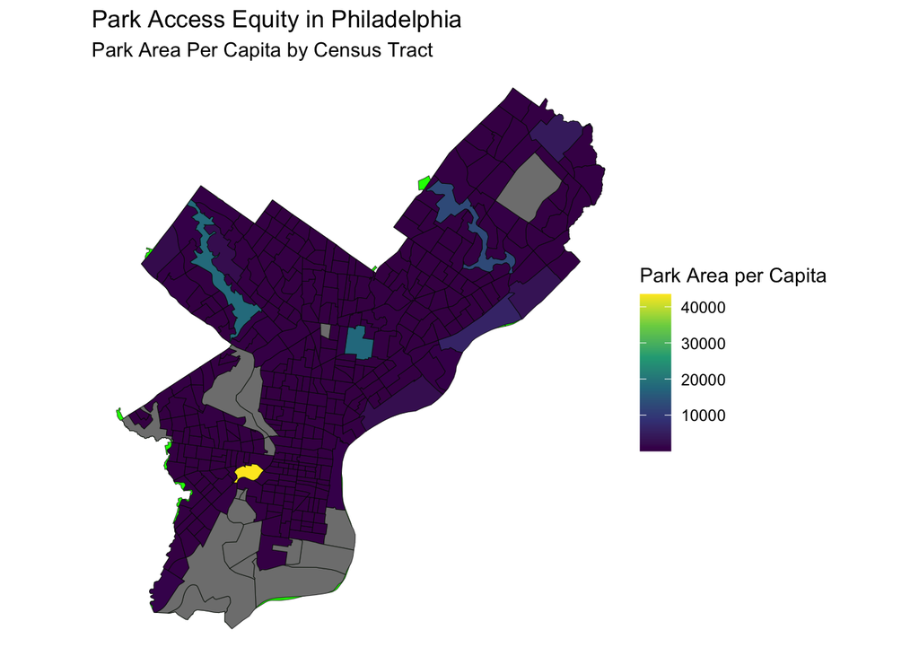

```r
#Spatial Mapping
ggplot() +
  geom_sf(data = parks, fill = "green") +
  geom_sf(data = phl_tracts, aes(fill = park_area_per_capita)) +
  scale_fill_viridis_c() +
  labs(
    title = "Park Access Equity in Philadelphia",
    subtitle = "Park Area Per Capita by Census Tract",
    fill = "Park Area per Capita"
  ) +
  theme_void()
```

**Analysis requirements:** - Clear code comments explaining each step - Appropriate CRS transformations - Summary statistics or counts - At least one map showing your findings - Brief interpretation of results (3-5 sentences)

**Your interpretation:**

**The analysis suggests that park access is unevenly distributed across Philadelphia. While many tracts are within 0.5 miles of a park, park acreage per capita varies significantly. Low-income tracts, on average, have lower park area per capita compared to higher-income tracts, indicating potential environmental justice concerns. Although spatial proximity may exist, the quantity and size of green space available to residents differ substantially, which has implications for climate resilience, heat mitigation, and public health outcomes.**

## Finally - A few comments about your incorporation of feedback!

**Compared to my first assignment, I incorporated feedback by improving CRS management and clearly transforming all spatial layers into a projected coordinate system before conducting distance and area calculations. Additionally, I strengthened my interpretation by distinguishing between percentage-based disparities and absolute population impacts, making the policy implications clearer.**

## Submission Requirements

**What to submit:**

1. **Rendered HTML document posted to your course portfolio** with all code, outputs, maps, and text
   - Use `embed-resources: true` in YAML so it’s a single file
   - All code should run without errors
   - All maps and charts should display correctly
2. Submit the correct and working links of your assignment on Canvas